# Zotero group LDR

Published

16 October 2026

Zotero data of 16 October 2026 · IPBES Literature Report 0.4.0 · [source code on GitHub](https://github.com/IPBES-Data/IPBES.LiteratureReport)

This report shows the state of the Zotero group **LDR** ([open the group in Zotero](https://www.zotero.org/groups/2333076)). It gives an overview of the literature in the group, and lists the items which should be corrected.

Each item in the lists can be opened in the Zotero **web** library or in the Zotero **app** on your computer, so that it can be corrected directly. Corrected items disappear from the lists the next time the report is updated. Some checks compare the items with [OpenAlex](https://openalex.org), an open catalogue of scholarly publications.

## Summary

[output not shown]

**Please fix**: these items contain errors. **Please check**: these items may need a correction. **For information**: no action needed unless the group uses this, e.g. tags.

## Items to fix

The lists are sorted by importance. Use the search field above a list to find an item. **web** opens the item in the Zotero web library, **app** in the Zotero app.

### Retracted publications

These publications have been retracted. Check whether they should still be cited, and mark or remove them in Zotero.

| Open in Zotero | Title | DOI |
| --- | --- | --- |
| <a href="https://www.zotero.org/groups/2333076/items/SHPWEJNE" target="_blank">web</a> &middot; <a href="zotero://select/groups/2333076/items/SHPWEJNE">app</a> | RETRACTED: Safety Evaluation and Risk Assessment of the Herbicide Roundup and Its Active Ingredient, Glyphosate, for Humans | <a href="https://doi.org/10.1006/rtph.1999.1371" target="_blank">10.1006/rtph.1999.1371</a> |

### DOI points to a different publication

The DOI of these items leads to a publication with a different title or year. Usually the DOI is wrong: open the DOI to see where it leads, and correct it in Zotero. Differences of one year (e.g. published online before print) are not listed.

| Open in Zotero | Title in Zotero | Year in Zotero | The DOI leads to | Its year | DOI |
| --- | --- | --- | --- | --- | --- |
| <a href="https://www.zotero.org/groups/2333076/items/5FFMVIXF" target="_blank">web</a> &middot; <a href="zotero://select/groups/2333076/items/5FFMVIXF">app</a> | The economic case for Landscaoe Restoration in Latin America - World Resources Institute (WRI) | 2016 | THE ECONOMIC CASE FOR LANDSCAPE RESTORATION IN LATIN AMERICA | 2016 | <a href="https://doi.org/10.13140/rg.2.2.13264.10243" target="_blank">10.13140/rg.2.2.13264.10243</a> |
| <a href="https://www.zotero.org/groups/2333076/items/DWWY2R6I" target="_blank">web</a> &middot; <a href="zotero://select/groups/2333076/items/DWWY2R6I">app</a> | Global Forest Resources Assessment 2015 | 2015 | Global patterns and controls of soil organic carbon dynamics as simulated by multiple terrestrial biosphere models: Current status and future directions | 2015 | <a href="https://doi.org/10.1002/2014gb005021" target="_blank">10.1002/2014gb005021</a> |
| <a href="https://www.zotero.org/groups/2333076/items/4HQNHAVR" target="_blank">web</a> &middot; <a href="zotero://select/groups/2333076/items/4HQNHAVR">app</a> | Summary for policymakers of the assessment report of the intergovernmental science-policy platform on biodiversity and ecosystem services (IPBES) on pollinators, pollination and food production | 2016 | Mosaic and Concerted Evolution in the Visual System of Birds | 2014 | <a href="https://doi.org/10.1371/journal.pone.0090102" target="_blank">10.1371/journal.pone.0090102</a> |
| <a href="https://www.zotero.org/groups/2333076/items/JLYV4V44" target="_blank">web</a> &middot; <a href="zotero://select/groups/2333076/items/JLYV4V44">app</a> | Environmental policy integration among multilateral environmental agreements: the case of biodiversity | 2016 | Environmental policy integration among multilateral environmental agreements: the case of biodiversity | 2014 | <a href="https://doi.org/10.1007/s10784-014-9263-4" target="_blank">10.1007/s10784-014-9263-4</a> |
| <a href="https://www.zotero.org/groups/2333076/items/TX94FTT6" target="_blank">web</a> &middot; <a href="zotero://select/groups/2333076/items/TX94FTT6">app</a> | Tropical forest insect pests: Ecology, impact, and management | 2007 | Tropical Forest Insect Pests | 2007 | <a href="https://doi.org/10.1017/cbo9780511542695" target="_blank">10.1017/cbo9780511542695</a> |
| <a href="https://www.zotero.org/groups/2333076/items/I3LYCGW6" target="_blank">web</a> &middot; <a href="zotero://select/groups/2333076/items/I3LYCGW6">app</a> | The biology of mangroves and seagrasses | 2013 | The biology of mangroves and seagrasses | 2008 | <a href="https://doi.org/10.5860/choice.45-3784" target="_blank">10.5860/choice.45-3784</a> |
| <a href="https://www.zotero.org/groups/2333076/items/XH5T7KSE" target="_blank">web</a> &middot; <a href="zotero://select/groups/2333076/items/XH5T7KSE">app</a> | Adoption of conservation agriculture in Europe. Lessons of the KASSA project | 2010 | Adoption of conservation agriculture in Europe | 2008 | <a href="https://doi.org/10.1016/j.landusepol.2008.02.001" target="_blank">10.1016/j.landusepol.2008.02.001</a> |
| <a href="https://www.zotero.org/groups/2333076/items/PBXHRHEH" target="_blank">web</a> &middot; <a href="zotero://select/groups/2333076/items/PBXHRHEH">app</a> | Restoring ecosystems, restoring community: socioeconomic and cultural dimensions of a community-based coral reef restoration project | 2016 | Restoring ecosystems, restoring community: socioeconomic and cultural dimensions of a community-based coral reef restoration project | 2013 | <a href="https://doi.org/10.1007/s10113-013-0572-x" target="_blank">10.1007/s10113-013-0572-x</a> |
| <a href="https://www.zotero.org/groups/2333076/items/W6FRQU49" target="_blank">web</a> &middot; <a href="zotero://select/groups/2333076/items/W6FRQU49">app</a> | Success of mowing to control yellow starthistle depends on timing and plant's branching form | 2009 | Success of mowing to control yellow starthistle depends on timing and plant's branching form | 1999 | <a href="https://doi.org/10.3733/ca.v053n02p17" target="_blank">10.3733/ca.v053n02p17</a> |
| <a href="https://www.zotero.org/groups/2333076/items/HUFJR5YF" target="_blank">web</a> &middot; <a href="zotero://select/groups/2333076/items/HUFJR5YF">app</a> | Ecotoxicological Risk Assessment for Roundup® Herbicide | 2011 | Ecotoxicological Risk Assessment for Roundup® Herbicide | 2000 | <a href="https://doi.org/10.1007/978-1-4612-1156-3_2" target="_blank">10.1007/978-1-4612-1156-3_2</a> |

[output cut: 221 more lines]

### Items which are in the group more than once

These items are in the group more than once, with the same DOI, or with the same title, year and first author. Keep one copy and merge or delete the others, e.g. with *Duplicate Items* in the Zotero app.

| Open in Zotero | Title | Copies |
| --- | --- | --- |
| <a href="https://www.zotero.org/groups/2333076/items/QBRU6UEV" target="_blank">web</a> &middot; <a href="zotero://select/groups/2333076/items/QBRU6UEV">app</a><br><a href="https://www.zotero.org/group… | Enhancement of Biodiversity and Ecosystem Services by Ecological Restoration: A Meta-Analysis | 2 |
| <a href="https://www.zotero.org/groups/2333076/items/BDGDMXPY" target="_blank">web</a> &middot; <a href="zotero://select/groups/2333076/items/BDGDMXPY">app</a><br><a href="https://www.zotero.org/group… | Evaluation and Selection of Indicators for Land Degradation and Desertification Monitoring: Types of Degradation, Causes, and Implications for Management | 2 |
| <a href="https://www.zotero.org/groups/2333076/items/UH86RHEJ" target="_blank">web</a> &middot; <a href="zotero://select/groups/2333076/items/UH86RHEJ">app</a><br><a href="https://www.zotero.org/group… | Introduction: The Growing Importance of Traditional Forest-Related Knowledge | 2 |
| <a href="https://www.zotero.org/groups/2333076/items/YME36H8S" target="_blank">web</a> &middot; <a href="zotero://select/groups/2333076/items/YME36H8S">app</a><br><a href="https://www.zotero.org/group… | Economics of land degradation and improvement - A global assessment for sustainable development | 3 |
| <a href="https://www.zotero.org/groups/2333076/items/SWSZZA43" target="_blank">web</a> &middot; <a href="zotero://select/groups/2333076/items/SWSZZA43">app</a><br><a href="https://www.zotero.org/group… | The Anthropocene is functionally and stratigraphically distinct from the Holocene | 2 |
| <a href="https://www.zotero.org/groups/2333076/items/NZ36AFVG" target="_blank">web</a> &middot; <a href="zotero://select/groups/2333076/items/NZ36AFVG">app</a><br><a href="https://www.zotero.org/group… | Land degradation in drylands: Interactions among hydrologic-aeolian erosion and vegetation dynamics | 2 |
| <a href="https://www.zotero.org/groups/2333076/items/MH9HBG2Z" target="_blank">web</a> &middot; <a href="zotero://select/groups/2333076/items/MH9HBG2Z">app</a><br><a href="https://www.zotero.org/group… | Bushmeat Exploitation in Tropical Forests: an Intercontinental Comparison | 2 |
| <a href="https://www.zotero.org/groups/2333076/items/JZPS2IDP" target="_blank">web</a> &middot; <a href="zotero://select/groups/2333076/items/JZPS2IDP">app</a><br><a href="https://www.zotero.org/group… | Creating space for large-scale restoration in tropical agricultural landscapes | 2 |
| <a href="https://www.zotero.org/groups/2333076/items/7M2LQUSR" target="_blank">web</a> &middot; <a href="zotero://select/groups/2333076/items/7M2LQUSR">app</a><br><a href="https://www.zotero.org/group… | Governing and delivering a biome-wide restoration initiative: The case of Atlantic Forest Restoration Pact in Brazil | 2 |
| <a href="https://www.zotero.org/groups/2333076/items/LBPJ72YK" target="_blank">web</a> &middot; <a href="zotero://select/groups/2333076/items/LBPJ72YK">app</a><br><a href="https://www.zotero.org/group… | Climate Change 2014 Mitigation of Climate Change | 2 |

[output cut: 6 more lines]

### DOI field with an invalid DOI

The DOI field of these items contains something which is not a valid DOI. Correct or remove it.

| Open in Zotero | Title | Content of the DOI field |
| --- | --- | --- |
| <a href="https://www.zotero.org/groups/2333076/items/SEKVG2TB" target="_blank">web</a> &middot; <a href="zotero://select/groups/2333076/items/SEKVG2TB">app</a> | Natural Capital Protocol – Principles and Framework | www.naturalcapitalcoalition.org |
| <a href="https://www.zotero.org/groups/2333076/items/DZEGSJ66" target="_blank">web</a> &middot; <a href="zotero://select/groups/2333076/items/DZEGSJ66">app</a> | Trends and Future Potential of Payment for Ecosystem Alleviate Rural Poverty in Developing Countries | n/a |
| <a href="https://www.zotero.org/groups/2333076/items/ME96AUGC" target="_blank">web</a> &middot; <a href="zotero://select/groups/2333076/items/ME96AUGC">app</a> | Land degradation and the Sustainable Development Goals: Threats and potential remedies | http://hdl.handle.net/10568/81313 |
| <a href="https://www.zotero.org/groups/2333076/items/WETSHDDE" target="_blank">web</a> &middot; <a href="zotero://select/groups/2333076/items/WETSHDDE">app</a> | Agroecology and Food Sovereignty | Article |
| <a href="https://www.zotero.org/groups/2333076/items/DRTV8AKE" target="_blank">web</a> &middot; <a href="zotero://select/groups/2333076/items/DRTV8AKE">app</a> | The Climate Change and Economic Impacts of Food Waste in the United States | 10.18461/ijfsd.v2i4.%x |
| <a href="https://www.zotero.org/groups/2333076/items/LHRWYYSH" target="_blank">web</a> &middot; <a href="zotero://select/groups/2333076/items/LHRWYYSH">app</a> | Global Assessment of Land Degradation and Improvement | report 2008/01 |
| <a href="https://www.zotero.org/groups/2333076/items/IVZ4J4L6" target="_blank">web</a> &middot; <a href="zotero://select/groups/2333076/items/IVZ4J4L6">app</a> | Using ecological thresholds to evaluate the costs and benefits of set-asides in a biodiversity hotspot | 0.1126/science.1255768 |
| <a href="https://www.zotero.org/groups/2333076/items/CNMXW6BJ" target="_blank">web</a> &middot; <a href="zotero://select/groups/2333076/items/CNMXW6BJ">app</a> | Ecosystem services: benefits supplied to human societies by natural ecosystems | 1092-8987 |

### DOI field with a link or prefix instead of the DOI

The DOI field of these items contains the DOI as a link (`https://doi.org/…`) or with a prefix (`DOI …`). Citation styles add the link themselves, so it would appear twice. Replace it with the DOI only.

| Open in Zotero | Title | Content of the DOI field | DOI |
| --- | --- | --- | --- |
| <a href="https://www.zotero.org/groups/2333076/items/4I4EEG5E" target="_blank">web</a> &middot; <a href="zotero://select/groups/2333076/items/4I4EEG5E">app</a> | A review of methods, data, and models to assess changes in the value of ecosystem services from land degradation and restoration | http://dx.doi.org/10.1016/j.ecolmodel.2015.07.017 | <a href="https://doi.org/10.1016/j.ecolmodel.2015.07.017" target="_blank">10.1016/j.ecolmodel.2015.07.017</a> |
| <a href="https://www.zotero.org/groups/2333076/items/J7X24FTW" target="_blank">web</a> &middot; <a href="zotero://select/groups/2333076/items/J7X24FTW">app</a> | Advancing the theory and practice of impact assessment: Setting the research agenda | http://dx.doi.org/10.1016/j.eiar.2013.01.008 | <a href="https://doi.org/10.1016/j.eiar.2013.01.008" target="_blank">10.1016/j.eiar.2013.01.008</a> |
| <a href="https://www.zotero.org/groups/2333076/items/DSPFRPZH" target="_blank">web</a> &middot; <a href="zotero://select/groups/2333076/items/DSPFRPZH">app</a> | Environmental impact assessment of urban land use transitions—A context-sensitive approach | http://dx.doi.org/10.1016/j.landusepol.2008.05.006 | <a href="https://doi.org/10.1016/j.landusepol.2008.05.006" target="_blank">10.1016/j.landusepol.2008.05.006</a> |
| <a href="https://www.zotero.org/groups/2333076/items/AJRTMZSR" target="_blank">web</a> &middot; <a href="zotero://select/groups/2333076/items/AJRTMZSR">app</a> | Global protected area expansion is compromised by projected land-use and parochialism | 10.1038/nature14032 http://www.nature.com/nature/journal/v516/n7531/abs/nature14032.html#supplementary-information | <a href="https://doi.org/10.1038/nature14032" target="_blank">10.1038/nature14032</a> |
| <a href="https://www.zotero.org/groups/2333076/items/NI9MLFCH" target="_blank">web</a> &middot; <a href="zotero://select/groups/2333076/items/NI9MLFCH">app</a> | Methods and workflow for spatial conservation prioritization using Zonation | http://dx.doi.org/10.1016/j.envsoft.2013.05.001 | <a href="https://doi.org/10.1016/j.envsoft.2013.05.001" target="_blank">10.1016/j.envsoft.2013.05.001</a> |
| <a href="https://www.zotero.org/groups/2333076/items/VPW8AHX9" target="_blank">web</a> &middot; <a href="zotero://select/groups/2333076/items/VPW8AHX9">app</a> | Landscape Zonation, benefit functions and target-based planning: Unifying reserve selection strategies | http://dx.doi.org/10.1016/j.biocon.2006.09.008 | <a href="https://doi.org/10.1016/j.biocon.2006.09.008" target="_blank">10.1016/j.biocon.2006.09.008</a> |
| <a href="https://www.zotero.org/groups/2333076/items/MJWRKQIU" target="_blank">web</a> &middot; <a href="zotero://select/groups/2333076/items/MJWRKQIU">app</a> | Towards a land management approach to ecological restoration to encourage stakeholder participation | http://dx.doi.org/10.1016/j.landusepol.2015.01.025 | <a href="https://doi.org/10.1016/j.landusepol.2015.01.025" target="_blank">10.1016/j.landusepol.2015.01.025</a> |
| <a href="https://www.zotero.org/groups/2333076/items/U9SBSJU9" target="_blank">web</a> &middot; <a href="zotero://select/groups/2333076/items/U9SBSJU9">app</a> | Quantifying the Benefits of Conservation Auctions: Evidence from an Economic Experiment | doi:10.1111/j.1746-692X.2007.00073.x | <a href="https://doi.org/10.1111/j.1746-692X.2007.00073.x" target="_blank">10.1111/j.1746-692X.2007.00073.x</a> |
| <a href="https://www.zotero.org/groups/2333076/items/RHIGP5TS" target="_blank">web</a> &middot; <a href="zotero://select/groups/2333076/items/RHIGP5TS">app</a> | A meta-analysis suggesting that the relationship between biodiversity and risk of zoonotic pathogen transmission is idiosyncratic | 10.1111/ele.12101 LK - http://sfx.umd.edu/hs?sid=EMBASE&issn=1461023X&id=doi:10.1111%2Fele.12101&atitle=A+meta-analysis+suggesting+that+the+relationship+between+biodiversity+and+risk+of+zoonotic+patho… | <a href="https://doi.org/10.1111/ele.12101" target="_blank">10.1111/ele.12101</a> |
| <a href="https://www.zotero.org/groups/2333076/items/G2R66MPB" target="_blank">web</a> &middot; <a href="zotero://select/groups/2333076/items/G2R66MPB">app</a> | Does natural resource extraction mitigate poverty and inequality? Evidence from rural Mexico and a Lacandona Rainforest Community | doi:10.1017/S1355770X06003494 | <a href="https://doi.org/10.1017/S1355770X06003494" target="_blank">10.1017/S1355770X06003494</a> |

[output cut: 25 more lines]

### ISSN not in the standard form

The ISSN field of these items is not in the standard form `1234-567X` (several separated by “,”), or contains something which is not a valid ISSN, e.g. an ISBN.

| Open in Zotero | Title | Content of the ISSN field | Standard form | Not a valid ISSN |
| --- | --- | --- | --- | --- |
| <a href="https://www.zotero.org/groups/2333076/items/MIBX8ZGL" target="_blank">web</a> &middot; <a href="zotero://select/groups/2333076/items/MIBX8ZGL">app</a> | From Framework to Action: The DESIRE Approach to Combat Desertification | 14321009 | 1432-1009 | NA |
| <a href="https://www.zotero.org/groups/2333076/items/VKNZYSUW" target="_blank">web</a> &middot; <a href="zotero://select/groups/2333076/items/VKNZYSUW">app</a> | Reducing emissions from land use in Indonesia: Motivation, policy instruments and expected funding streams | 13812386 | 1381-2386 | NA |
| <a href="https://www.zotero.org/groups/2333076/items/XIN343EP" target="_blank">web</a> &middot; <a href="zotero://select/groups/2333076/items/XIN343EP">app</a> | Impact of multiple interacting financial incentives on land use change and the supply of ecosystem services | 22120416 | 2212-0416 | NA |
| <a href="https://www.zotero.org/groups/2333076/items/YCYFVLWS" target="_blank">web</a> &middot; <a href="zotero://select/groups/2333076/items/YCYFVLWS">app</a> | Multi-criteria decision analysis to select metrics for design and monitoring of sustainable ecosystem restorations | 1470160X | 1470-160X | NA |
| <a href="https://www.zotero.org/groups/2333076/items/7VX74N5F" target="_blank">web</a> &middot; <a href="zotero://select/groups/2333076/items/7VX74N5F">app</a> | From Management to Stewardship: Viewing Forests As Complex Adaptive Systems in an Uncertain World | 1755263X | 1755-263X | NA |
| <a href="https://www.zotero.org/groups/2333076/items/AN92M8LX" target="_blank">web</a> &middot; <a href="zotero://select/groups/2333076/items/AN92M8LX">app</a> | A New Dryland Development Paradigm Grounded in Empirical Analysis of Dryland Systems Science | 1099145X | 1099-145X | NA |
| <a href="https://www.zotero.org/groups/2333076/items/272YDBSB" target="_blank">web</a> &middot; <a href="zotero://select/groups/2333076/items/272YDBSB">app</a> | Prioritization of forest restoration projects: Tradeoffs between wildfire protection, ecological restoration and economic objectives | 19994907 | 1999-4907 | NA |
| <a href="https://www.zotero.org/groups/2333076/items/7FKXR6FX" target="_blank">web</a> &middot; <a href="zotero://select/groups/2333076/items/7FKXR6FX">app</a> | Land degradation assessment in southern Africa: Integrating local and scientific knowledge bases | 10853278 | 1085-3278 | NA |
| <a href="https://www.zotero.org/groups/2333076/items/UY34QJKF" target="_blank">web</a> &middot; <a href="zotero://select/groups/2333076/items/UY34QJKF">app</a> | Resource-conserving agriculture increases yields in developing countries | 0013936X | 0013-936X | NA |
| <a href="https://www.zotero.org/groups/2333076/items/GYYZ3R9T" target="_blank">web</a> &middot; <a href="zotero://select/groups/2333076/items/GYYZ3R9T">app</a> | Cross-scale monitoring and assessment of land degradation and sustainable land management: A methodological framework for knowledge management | 10853278 | 1085-3278 | NA |

[output cut: 1909 more lines]

### DOI in the wrong field

These items have no DOI in the DOI field, but a DOI in the URL or Extra field. Copy the DOI into the DOI field.

| Open in Zotero | Title | DOI in URL | DOI in Extra |
| --- | --- | --- | --- |
| <a href="https://www.zotero.org/groups/2333076/items/9U6678C3" target="_blank">web</a> &middot; <a href="zotero://select/groups/2333076/items/9U6678C3">app</a> | Mapping the Global Emergence of Batrachochytrium dendrobatidis, the Amphibian Chytrid Fungus | <a href="https://doi.org/10.1371/journal.pone.0056802" target="_blank">10.1371/journal.pone.0056802</a> |  |
| <a href="https://www.zotero.org/groups/2333076/items/RG96CW5W" target="_blank">web</a> &middot; <a href="zotero://select/groups/2333076/items/RG96CW5W">app</a> | Connectivity and the Governance of Multilevel Social-Ecological Systems: The Role of Social Capital | <a href="https://doi.org/10.1146/annurev.environ.020708.100707" target="_blank">10.1146/annurev.environ.020708.100707</a> |  |
| <a href="https://www.zotero.org/groups/2333076/items/445L7MVI" target="_blank">web</a> &middot; <a href="zotero://select/groups/2333076/items/445L7MVI">app</a> | Regime complexes and national policy coherence: Experiences in the biodiversity cluster | <a href="https://doi.org/10.5555/1075-2846-20.1.119" target="_blank">10.5555/1075-2846-20.1.119</a> |  |
| <a href="https://www.zotero.org/groups/2333076/items/4NXVNLLQ" target="_blank">web</a> &middot; <a href="zotero://select/groups/2333076/items/4NXVNLLQ">app</a> | Mechanized Direct-Seeding of Native Forests in Xingu, Central Brazil | <a href="https://doi.org/10.1080/10549811.2013.817341" target="_blank">10.1080/10549811.2013.817341</a> |  |
| <a href="https://www.zotero.org/groups/2333076/items/TD9IP3EW" target="_blank">web</a> &middot; <a href="zotero://select/groups/2333076/items/TD9IP3EW">app</a> | Workingsci2.Qk | <a href="https://doi.org/10.1289/ehp.6877" target="_blank">10.1289/ehp.6877</a> |  |
| <a href="https://www.zotero.org/groups/2333076/items/EEXJP833" target="_blank">web</a> &middot; <a href="zotero://select/groups/2333076/items/EEXJP833">app</a> | Historical Warnings of Future Food Insecurity with Unprecedented Seasonal Heat | <a href="https://doi.org/10.1126/science.1245938" target="_blank">10.1126/science.1245938</a> |  |
| <a href="https://www.zotero.org/groups/2333076/items/WVU5XPCJ" target="_blank">web</a> &middot; <a href="zotero://select/groups/2333076/items/WVU5XPCJ">app</a> | Cultural Dimensions of Climate Change | <a href="https://doi.org/10.1038/nclimate1666" target="_blank">10.1038/nclimate1666</a> |  |
| <a href="https://www.zotero.org/groups/2333076/items/WSFJJVUM" target="_blank">web</a> &middot; <a href="zotero://select/groups/2333076/items/WSFJJVUM">app</a> | From euphoria to reality on efforts to reduce emissions from deforestation and forest degradation (REDD+) | <a href="https://doi.org/10.1007/s11027-014-9577-0.pdf" target="_blank">10.1007/s11027-014-9577-0.pdf</a> |  |
| <a href="https://www.zotero.org/groups/2333076/items/IDUC539F" target="_blank">web</a> &middot; <a href="zotero://select/groups/2333076/items/IDUC539F">app</a> | What counts? Volunteers and their organisations in the recording and monitoring of biodiversity | <a href="https://doi.org/10.1007/s10531-008-9357-9" target="_blank">10.1007/s10531-008-9357-9</a> |  |
| <a href="https://www.zotero.org/groups/2333076/items/Y3ALWPRL" target="_blank">web</a> &middot; <a href="zotero://select/groups/2333076/items/Y3ALWPRL">app</a> | Nature and the Life Course : Pathways from Childhood Nature to Adult Environmentalism | <a href="https://doi.org/10.7721/chilyoutenvi.16.1.0001" target="_blank">10.7721/chilyoutenvi.16.1.0001</a> |  |

[output cut: 53 more lines]

### DOI not found in OpenAlex

These DOIs were not found in OpenAlex. The DOI may be wrong: open it to check. If it leads to the right publication, the publication is simply not (yet) in OpenAlex and nothing needs to be done.

| Open in Zotero | Title | DOI |
| --- | --- | --- |
| <a href="https://www.zotero.org/groups/2333076/items/U8ASWLTP" target="_blank">web</a> &middot; <a href="zotero://select/groups/2333076/items/U8ASWLTP">app</a> | Report on best practices for limiting soil sealing and mitigating its effects. Technical Report 2011-050, European Commission, European Communities | <a href="https://doi.org/10.2779/15146" target="_blank">10.2779/15146</a> |
| <a href="https://www.zotero.org/groups/2333076/items/BFE6J3MM" target="_blank">web</a> &middot; <a href="zotero://select/groups/2333076/items/BFE6J3MM">app</a> | Environment and Behavior NEARBY NATURE A Buffer of Life Stress Among Rural Children | <a href="https://doi.org/10.1177/0013916503251445" target="_blank">10.1177/0013916503251445</a> |
| <a href="https://www.zotero.org/groups/2333076/items/D69KRXI7" target="_blank">web</a> &middot; <a href="zotero://select/groups/2333076/items/D69KRXI7">app</a> | Agriculture for Development | <a href="https://doi.org/10.1596/978-0-8213-7233-3" target="_blank">10.1596/978-0-8213-7233-3</a> |
| <a href="https://www.zotero.org/groups/2333076/items/U3JA7NX5" target="_blank">web</a> &middot; <a href="zotero://select/groups/2333076/items/U3JA7NX5">app</a> | World development report: Development and the environment | <a href="https://doi.org/10.1596/978-0-19-520876-4" target="_blank">10.1596/978-0-19-520876-4</a> |
| <a href="https://www.zotero.org/groups/2333076/items/CAG7Z3JE" target="_blank">web</a> &middot; <a href="zotero://select/groups/2333076/items/CAG7Z3JE">app</a> | Global patterns of zoological disease in mammals | <a href="https://doi.org/10.1016/j.pt.2016.04.007.global" target="_blank">10.1016/j.pt.2016.04.007.global</a> |
| <a href="https://www.zotero.org/groups/2333076/items/EYEZMLVV" target="_blank">web</a> &middot; <a href="zotero://select/groups/2333076/items/EYEZMLVV">app</a> | Does Drought Increase Migration? A Study of Migration from Rural Mali during the 1983-1985 Drought | <a href="https://doi.org/10.2307/2546820" target="_blank">10.2307/2546820</a> |
| <a href="https://www.zotero.org/groups/2333076/items/AH2TZRYH" target="_blank">web</a> &middot; <a href="zotero://select/groups/2333076/items/AH2TZRYH">app</a> | Mapping the economic costs and benefits of conservation .pbio.0040360.pdf | <a href="https://doi.org/10.1371/journal.pbio.0040360.t004" target="_blank">10.1371/journal.pbio.0040360.t004</a> |
| <a href="https://www.zotero.org/groups/2333076/items/NIV988DG" target="_blank">web</a> &middot; <a href="zotero://select/groups/2333076/items/NIV988DG">app</a> | Global Land-Use/Land-Cover Change: Towards an Integrated Study | <a href="https://doi.org/10.2307/4314168" target="_blank">10.2307/4314168</a> |
| <a href="https://www.zotero.org/groups/2333076/items/TC7ZW8WY" target="_blank">web</a> &middot; <a href="zotero://select/groups/2333076/items/TC7ZW8WY">app</a> | Natural fire frequency for the eastern Canadian boreal forest: consequences for sustainable forestry | <a href="https://doi.org/10.1139/x00-178" target="_blank">10.1139/x00-178</a> |
| <a href="https://www.zotero.org/groups/2333076/items/AFSXXIXR" target="_blank">web</a> &middot; <a href="zotero://select/groups/2333076/items/AFSXXIXR">app</a> | Effects in of Habitat Fragmentation on Forest Bird Species Chile a Relict Temperate Semiarid | <a href="https://doi.org/10.2307/2641618" target="_blank">10.2307/2641618</a> |

[output cut: 17 more lines]

### Missing or unusual publication year

These items have no date, a date from which no year could be read, or a year in the future. Correct the date in Zotero.

| Open in Zotero | Title | Date | Problem | Date in OpenAlex |
| --- | --- | --- | --- | --- |
| <a href="https://www.zotero.org/groups/2333076/items/VMX7F9AU" target="_blank">web</a> &middot; <a href="zotero://select/groups/2333076/items/VMX7F9AU">app</a> | Centre for Indigenous Peoples' Nutrition and Environment |  | No date | NA |
| <a href="https://www.zotero.org/groups/2333076/items/LN7FI54W" target="_blank">web</a> &middot; <a href="zotero://select/groups/2333076/items/LN7FI54W">app</a> | Ecosystem Services Valuation — Earth Economics |  | No date | NA |
| <a href="https://www.zotero.org/groups/2333076/items/VDASGUEC" target="_blank">web</a> &middot; <a href="zotero://select/groups/2333076/items/VDASGUEC">app</a> | Biennial review and assessment of the world timber situation 2015-2016 |  | No date | NA |
| <a href="https://www.zotero.org/groups/2333076/items/8A7BAMQS" target="_blank">web</a> &middot; <a href="zotero://select/groups/2333076/items/8A7BAMQS">app</a> | Facts & Figures |  | No date | NA |
| <a href="https://www.zotero.org/groups/2333076/items/JK3SXBQ9" target="_blank">web</a> &middot; <a href="zotero://select/groups/2333076/items/JK3SXBQ9">app</a> | Restoration of degraded land: contributing to Aichi targets 14, 15, and beyond |  | No date | NA |
| <a href="https://www.zotero.org/groups/2333076/items/6GGUH8CB" target="_blank">web</a> &middot; <a href="zotero://select/groups/2333076/items/6GGUH8CB">app</a> | Solidarité |  | No date | NA |
| <a href="https://www.zotero.org/groups/2333076/items/5PIFDG4C" target="_blank">web</a> &middot; <a href="zotero://select/groups/2333076/items/5PIFDG4C">app</a> | Africa's green revolution : critical perspectives on new agricultural technologies and systems |  | No date | NA |
| <a href="https://www.zotero.org/groups/2333076/items/EZYAXJCA" target="_blank">web</a> &middot; <a href="zotero://select/groups/2333076/items/EZYAXJCA">app</a> | Submerged to Floating Plants.In: Regime Shifts Database, www.regimeshifts.org |  | No date | NA |
| <a href="https://www.zotero.org/groups/2333076/items/Z9VJPX6I" target="_blank">web</a> &middot; <a href="zotero://select/groups/2333076/items/Z9VJPX6I">app</a> | Target 15: Ecosystem Restoration and Resilience |  | No date | NA |
| <a href="https://www.zotero.org/groups/2333076/items/JJLGTUPC" target="_blank">web</a> &middot; <a href="zotero://select/groups/2333076/items/JJLGTUPC">app</a> | Richards Bay Minerals dune mining, South Africa |  | No date | NA |

[output cut: 2 more lines]

### Empty journal, volume, issue or pages, found in OpenAlex

These journal articles have an empty journal, volume, issue or pages field, and OpenAlex has the value for their DOI. Check it with the DOI and fill in the field.

| Open in Zotero | Title | Field | Value in OpenAlex | DOI |
| --- | --- | --- | --- | --- |
| <a href="https://www.zotero.org/groups/2333076/items/TBNSTFB9" target="_blank">web</a> &middot; <a href="zotero://select/groups/2333076/items/TBNSTFB9">app</a> | "Grain for green" driven land use change and carbon sequestration on the Loess Plateau, China | Issue | 1 | <a href="https://doi.org/10.1038/srep07039" target="_blank">10.1038/srep07039</a> |
| <a href="https://www.zotero.org/groups/2333076/items/G335K5ET" target="_blank">web</a> &middot; <a href="zotero://select/groups/2333076/items/G335K5ET">app</a> | A comprehensive analysis on spread and distribution characteristic of antibiotic resistance genes in livestock farms of Southeastern China | Pages | e0156889 | <a href="https://doi.org/10.1371/journal.pone.0156889" target="_blank">10.1371/journal.pone.0156889</a> |
| <a href="https://www.zotero.org/groups/2333076/items/KJT7DMBD" target="_blank">web</a> &middot; <a href="zotero://select/groups/2333076/items/KJT7DMBD">app</a> | A new map of global urban extent from MODIS satellite data | Pages | 044003 | <a href="https://doi.org/10.1088/1748-9326/4/4/044003" target="_blank">10.1088/1748-9326/4/4/044003</a> |
| <a href="https://www.zotero.org/groups/2333076/items/LMX9ADE3" target="_blank">web</a> &middot; <a href="zotero://select/groups/2333076/items/LMX9ADE3">app</a> | A process for assessing the offsetability of biodiversity impacts | Volume | 6 | <a href="https://doi.org/10.1111/conl.12002" target="_blank">10.1111/conl.12002</a> |
| <a href="https://www.zotero.org/groups/2333076/items/LMX9ADE3" target="_blank">web</a> &middot; <a href="zotero://select/groups/2333076/items/LMX9ADE3">app</a> | A process for assessing the offsetability of biodiversity impacts | Issue | 5 | <a href="https://doi.org/10.1111/conl.12002" target="_blank">10.1111/conl.12002</a> |
| <a href="https://www.zotero.org/groups/2333076/items/RM89KFIL" target="_blank">web</a> &middot; <a href="zotero://select/groups/2333076/items/RM89KFIL">app</a> | Adaptive Strategies to Displacement and Environmental Change Among the Kaiabi Indigenous People of the Brazilian Amazon | Volume | 31 | <a href="https://doi.org/10.1080/08941920.2018.1426801" target="_blank">10.1080/08941920.2018.1426801</a> |
| <a href="https://www.zotero.org/groups/2333076/items/RM89KFIL" target="_blank">web</a> &middot; <a href="zotero://select/groups/2333076/items/RM89KFIL">app</a> | Adaptive Strategies to Displacement and Environmental Change Among the Kaiabi Indigenous People of the Brazilian Amazon | Issue | 6 | <a href="https://doi.org/10.1080/08941920.2018.1426801" target="_blank">10.1080/08941920.2018.1426801</a> |
| <a href="https://www.zotero.org/groups/2333076/items/EC7JPDJE" target="_blank">web</a> &middot; <a href="zotero://select/groups/2333076/items/EC7JPDJE">app</a> | Adult odonate abundance and community assemblage measures as indicators of stream ecological integrity: A case study | Issue | 3 | <a href="https://doi.org/10.1016/j.ecolind.2009.12.004" target="_blank">10.1016/j.ecolind.2009.12.004</a> |
| <a href="https://www.zotero.org/groups/2333076/items/85PX5KNQ" target="_blank">web</a> &middot; <a href="zotero://select/groups/2333076/items/85PX5KNQ">app</a> | Africa and the Green Revolution A Global Historical Perspective | Issue | 1 | <a href="https://doi.org/10.1016/j.njas.2014.01.003" target="_blank">10.1016/j.njas.2014.01.003</a> |
| <a href="https://www.zotero.org/groups/2333076/items/SHJD52AC" target="_blank">web</a> &middot; <a href="zotero://select/groups/2333076/items/SHJD52AC">app</a> | Agricultural sustainability: concepts, principles and evidence | Pages | 447-465 | <a href="https://doi.org/10.1098/rstb.2007.2163" target="_blank">10.1098/rstb.2007.2163</a> |

[output cut: 96 more lines]

### Language not given as a language code

The language of these items is not given as a language code (`en`, `fr`, `en-US`), e.g. as `English` or `eng`. Citation styles only recognise the codes. Where the language was recognised, the code is shown; otherwise look up the code in the [ISO 639-1 list](https://en.wikipedia.org/wiki/List_of_ISO_639_language_codes).

| Open in Zotero | Title | Language | Language code |
| --- | --- | --- | --- |
| <a href="https://www.zotero.org/groups/2333076/items/ANL7MGHJ" target="_blank">web</a> &middot; <a href="zotero://select/groups/2333076/items/ANL7MGHJ">app</a> | Carbon sequestration in drylands | English | en |
| <a href="https://www.zotero.org/groups/2333076/items/IYHJ5KW2" target="_blank">web</a> &middot; <a href="zotero://select/groups/2333076/items/IYHJ5KW2">app</a> | Global forest resources assessment 2015: how are the world’s forests changing? | eng | en |
| <a href="https://www.zotero.org/groups/2333076/items/LQIZH2ZY" target="_blank">web</a> &middot; <a href="zotero://select/groups/2333076/items/LQIZH2ZY">app</a> | Addressing Land Degradation: Benefits, Costs, and Policy Directions | English | en |
| <a href="https://www.zotero.org/groups/2333076/items/369ML35K" target="_blank">web</a> &middot; <a href="zotero://select/groups/2333076/items/369ML35K">app</a> | Soil Conservation Behavior and Attitudes among Ontario Farmers toward Alternative Government Policy Responses | English | en |
| <a href="https://www.zotero.org/groups/2333076/items/VL4GUXBA" target="_blank">web</a> &middot; <a href="zotero://select/groups/2333076/items/VL4GUXBA">app</a> | Soil erosion assessment and control in Northeast Wollega, Ethiopia | English | en |
| <a href="https://www.zotero.org/groups/2333076/items/F22D2WJY" target="_blank">web</a> &middot; <a href="zotero://select/groups/2333076/items/F22D2WJY">app</a> | Price Policy and Returns to Soil Conservation in Semi-Arid Kenya | English | en |
| <a href="https://www.zotero.org/groups/2333076/items/H8I8ZU7K" target="_blank">web</a> &middot; <a href="zotero://select/groups/2333076/items/H8I8ZU7K">app</a> | Environmental Impact Assessment: Challenges in Use of Methods and Tools in France and in Russia | EN | en |
| <a href="https://www.zotero.org/groups/2333076/items/TJDA9WZY" target="_blank">web</a> &middot; <a href="zotero://select/groups/2333076/items/TJDA9WZY">app</a> | The Oxford handbook of transformations of the state | English | en |
| <a href="https://www.zotero.org/groups/2333076/items/VGR2QH3Z" target="_blank">web</a> &middot; <a href="zotero://select/groups/2333076/items/VGR2QH3Z">app</a> | Policy modelling of the trade-off between agricultural development and land degradation - the Sudan case | English | en |
| <a href="https://www.zotero.org/groups/2333076/items/6MDKVYVD" target="_blank">web</a> &middot; <a href="zotero://select/groups/2333076/items/6MDKVYVD">app</a> | Indigenous peoples' food systems & well-being: interventions & policies for healthy communities | eng | en |

[output cut: 40 more lines]

### Items without DOI, ISBN, ISSN or URL

Readers cannot easily find these items. Add a DOI, ISBN, ISSN or URL if one exists. Some items, e.g. personal communications, have none.

| Open in Zotero | Title | Type |
| --- | --- | --- |
| <a href="https://www.zotero.org/groups/2333076/items/6AJKRXSX" target="_blank">web</a> &middot; <a href="zotero://select/groups/2333076/items/6AJKRXSX">app</a> | The ecosystem approach and the precautionary principle | book section |
| <a href="https://www.zotero.org/groups/2333076/items/LEG3BKP9" target="_blank">web</a> &middot; <a href="zotero://select/groups/2333076/items/LEG3BKP9">app</a> | Nature capital: valuation and payments for eco- system services | book section |
| <a href="https://www.zotero.org/groups/2333076/items/TDL2DNQN" target="_blank">web</a> &middot; <a href="zotero://select/groups/2333076/items/TDL2DNQN">app</a> | Environment Law, Regulation and Governance: Shifting Architectures | journal article |
| <a href="https://www.zotero.org/groups/2333076/items/CL79ICMY" target="_blank">web</a> &middot; <a href="zotero://select/groups/2333076/items/CL79ICMY">app</a> | Towards a Land Degradation Neutral World - A Sustainable Development Priority | report |
| <a href="https://www.zotero.org/groups/2333076/items/ABTK6Q6D" target="_blank">web</a> &middot; <a href="zotero://select/groups/2333076/items/ABTK6Q6D">app</a> | Transforming Land Management Globally | report |
| <a href="https://www.zotero.org/groups/2333076/items/QE22B3WM" target="_blank">web</a> &middot; <a href="zotero://select/groups/2333076/items/QE22B3WM">app</a> | Pan-European soil erosion risk assessment for Europe: the PESERA Map | report |
| <a href="https://www.zotero.org/groups/2333076/items/GNFZ9Y2G" target="_blank">web</a> &middot; <a href="zotero://select/groups/2333076/items/GNFZ9Y2G">app</a> | Sketch of the botany of Otago | conference paper |
| <a href="https://www.zotero.org/groups/2333076/items/IQUU7ZS9" target="_blank">web</a> &middot; <a href="zotero://select/groups/2333076/items/IQUU7ZS9">app</a> | Crown Pastoral Land Act 1998. Public Act 1998, No 65 | book |
| <a href="https://www.zotero.org/groups/2333076/items/Y64LWG26" target="_blank">web</a> &middot; <a href="zotero://select/groups/2333076/items/Y64LWG26">app</a> | Decision making and problem solving | book |
| <a href="https://www.zotero.org/groups/2333076/items/RT8PXL93" target="_blank">web</a> &middot; <a href="zotero://select/groups/2333076/items/RT8PXL93">app</a> | UNEP Stories, Do we have a right to a healthy environment? | book |

[output cut: 561 more lines]

### Items without DOI, for which OpenAlex has one

OpenAlex was searched by title for items without a DOI (journal articles, books, book sections, reports, conference papers, theses, preprints). The publications found are compared by title, year and first author: a *likely* match agrees in all three, a *possible* match has a similar title, but e.g. a different year or author. Open the DOI to check that it is the same publication, and add the DOI in Zotero.

| Open in Zotero | Title | Year | Author | Found in OpenAlex | Year (OpenAlex) | Author (OpenAlex) | Match | DOI |
| --- | --- | --- | --- | --- | --- | --- | --- | --- |
| <a href="https://www.zotero.org/groups/2333076/items/FAY5YC4S" target="_blank">web</a> &middot; <a href="zotero://select/groups/2333076/items/FAY5YC4S">app</a> | 'Ecosystems' | 2007 | Tarlock, D | ECOSystem | 2002 | Heng Zeng | possible | <a href="https://doi.org/10.1145/605397.605411" target="_blank">10.1145/605397.605411</a> |
| <a href="https://www.zotero.org/groups/2333076/items/66TTIX2S" target="_blank">web</a> &middot; <a href="zotero://select/groups/2333076/items/66TTIX2S">app</a> | 'Stinking, disease-spreading brutes' or'four-legged landscape managers'? Livestock, pastoralism and society in Germany and the USA | 2003 | Bieling, C | ‘Stinking, Disease-Spreading Brutes’ or ‘Four-Legged Landscape Managers’? Livestock, Pastoralism and Society in Germany and the USA | 2003 | Claudia Bieling | likely | <a href="https://doi.org/10.5367/000000003101294208" target="_blank">10.5367/000000003101294208</a> |
| <a href="https://www.zotero.org/groups/2333076/items/ZREPYE5J" target="_blank">web</a> &middot; <a href="zotero://select/groups/2333076/items/ZREPYE5J">app</a> | [World population prospects]. | 1990 | Parant, A | World Population Prospects | 2012 | United Nations | possible | <a href="https://doi.org/10.18356/08b807d4-en" target="_blank">10.18356/08b807d4-en</a> |
| <a href="https://www.zotero.org/groups/2333076/items/ZREPYE5J" target="_blank">web</a> &middot; <a href="zotero://select/groups/2333076/items/ZREPYE5J">app</a> | [World population prospects]. | 1990 | Parant, A | World Population Prospects | 2013 | United Nations Department of Economic and Social Affairs | possible | <a href="https://doi.org/10.18356/02911eeb-en" target="_blank">10.18356/02911eeb-en</a> |
| <a href="https://www.zotero.org/groups/2333076/items/ZREPYE5J" target="_blank">web</a> &middot; <a href="zotero://select/groups/2333076/items/ZREPYE5J">app</a> | [World population prospects]. | 1990 | Parant, A | World Population Prospects | 2016 | United Nations Department of Economic and Social Affairs | possible | <a href="https://doi.org/10.18356/a3bacd57-en" target="_blank">10.18356/a3bacd57-en</a> |
| <a href="https://www.zotero.org/groups/2333076/items/ZREPYE5J" target="_blank">web</a> &middot; <a href="zotero://select/groups/2333076/items/ZREPYE5J">app</a> | [World population prospects]. | 1990 | Parant, A | World Population Prospects 2022 | 2022 | United Nations | possible | <a href="https://doi.org/10.18356/9789210014380" target="_blank">10.18356/9789210014380</a> |
| <a href="https://www.zotero.org/groups/2333076/items/4X7FE49C" target="_blank">web</a> &middot; <a href="zotero://select/groups/2333076/items/4X7FE49C">app</a> | A comparison of cultivation and wild collection of medicinal and aromatic plants under sustainability aspects | 2006 | Schippmann, U. W. E. | A Comparison of Cultivation and Wild Collection of Medicinal and Aromatic Plants Under Sustainability Aspects | 2007 | U. Schippmann | likely | <a href="https://doi.org/10.1007/1-4020-5449-1_6" target="_blank">10.1007/1-4020-5449-1_6</a> |
| <a href="https://www.zotero.org/groups/2333076/items/H686CEDP" target="_blank">web</a> &middot; <a href="zotero://select/groups/2333076/items/H686CEDP">app</a> | A critique of the ‘novel ecosystem'concept | 2014 | Murcia, Carolina | A critique of the ‘novel ecosystem’ concept | 2014 | Carolina Murcia | likely | <a href="https://doi.org/10.1016/j.tree.2014.07.006" target="_blank">10.1016/j.tree.2014.07.006</a> |
| <a href="https://www.zotero.org/groups/2333076/items/SNSVC538" target="_blank">web</a> &middot; <a href="zotero://select/groups/2333076/items/SNSVC538">app</a> | A human-driven decline in global burned area | 2017 | Andela, N | A human-driven decline in global burned area | 2017 | Niels Andela | likely | <a href="https://doi.org/10.1126/science.aal4108" target="_blank">10.1126/science.aal4108</a> |
| <a href="https://www.zotero.org/groups/2333076/items/ML9K8BQV" target="_blank">web</a> &middot; <a href="zotero://select/groups/2333076/items/ML9K8BQV">app</a> | A meta-analysis of crop yield under climate change and adaptation | 2014 | Challinor, A. J. | A meta-analysis of crop yield under climate change and adaptation | 2014 | Andrew Juan Challinor | likely | <a href="https://doi.org/10.1038/nclimate2153" target="_blank">10.1038/nclimate2153</a> |

[output cut: 663 more lines]

### OpenAlex ID in Extra not valid

The line `OpenAlex: …` in the Extra field of these items is not an OpenAlex ID, is not in OpenAlex (wrong, or the record was merged into another one), or leads to a different publication. Open the item and the OpenAlex record to check, and correct or remove the line.

**✔ Nothing to fix.**

### Items without their OpenAlex ID in Extra

These items were found in OpenAlex by their DOI, but their Extra field has no line `OpenAlex: W…` with the ID of the publication in OpenAlex, or a different one. The ID links the item to OpenAlex. A different ID can come from OpenAlex merging records; open both to check.

| Open in Zotero | Title | OpenAlex ID | ID in Extra | DOI |
| --- | --- | --- | --- | --- |
| <a href="https://www.zotero.org/groups/2333076/items/QBRU6UEV" target="_blank">web</a> &middot; <a href="zotero://select/groups/2333076/items/QBRU6UEV">app</a> | Enhancement of Biodiversity and Ecosystem Services by Ecological Restoration: A Meta-Analysis | W2068464578 | NA | <a href="https://doi.org/10.1126/science.1172460" target="_blank">10.1126/science.1172460</a> |
| <a href="https://www.zotero.org/groups/2333076/items/5SJQLRXB" target="_blank">web</a> &middot; <a href="zotero://select/groups/2333076/items/5SJQLRXB">app</a> | Characterizing Forest Change Using Community-Based Monitoring Data and Landsat Time Series | W2328006415 | NA | <a href="https://doi.org/10.1371/journal.pone.0147121" target="_blank">10.1371/journal.pone.0147121</a> |
| <a href="https://www.zotero.org/groups/2333076/items/5T9QH3H8" target="_blank">web</a> &middot; <a href="zotero://select/groups/2333076/items/5T9QH3H8">app</a> | Environmental decision support systems (EDSS) development – Challenges and best practices | W2037150067 | NA | <a href="https://doi.org/10.1016/j.envsoft.2011.09.009" target="_blank">10.1016/j.envsoft.2011.09.009</a> |
| <a href="https://www.zotero.org/groups/2333076/items/4I4EEG5E" target="_blank">web</a> &middot; <a href="zotero://select/groups/2333076/items/4I4EEG5E">app</a> | A review of methods, data, and models to assess changes in the value of ecosystem services from land degradation and restoration | W2200532224 | NA | <a href="https://doi.org/10.1016/j.ecolmodel.2015.07.017" target="_blank">10.1016/j.ecolmodel.2015.07.017</a> |
| <a href="https://www.zotero.org/groups/2333076/items/MIBX8ZGL" target="_blank">web</a> &middot; <a href="zotero://select/groups/2333076/items/MIBX8ZGL">app</a> | From Framework to Action: The DESIRE Approach to Combat Desertification | W2037829415 | NA | <a href="https://doi.org/10.1007/s00267-014-0346-3" target="_blank">10.1007/s00267-014-0346-3</a> |
| <a href="https://www.zotero.org/groups/2333076/items/J7X24FTW" target="_blank">web</a> &middot; <a href="zotero://select/groups/2333076/items/J7X24FTW">app</a> | Advancing the theory and practice of impact assessment: Setting the research agenda | W2046725094 | NA | <a href="https://doi.org/10.1016/j.eiar.2013.01.008" target="_blank">10.1016/j.eiar.2013.01.008</a> |
| <a href="https://www.zotero.org/groups/2333076/items/VKNZYSUW" target="_blank">web</a> &middot; <a href="zotero://select/groups/2333076/items/VKNZYSUW">app</a> | Reducing emissions from land use in Indonesia: Motivation, policy instruments and expected funding streams | W2167383704 | NA | <a href="https://doi.org/10.1007/s11027-013-9502-y" target="_blank">10.1007/s11027-013-9502-y</a> |
| <a href="https://www.zotero.org/groups/2333076/items/Q8UTFE7S" target="_blank">web</a> &middot; <a href="zotero://select/groups/2333076/items/Q8UTFE7S">app</a> | Natural capital and ecosystem services informing decisions: From promise to practice | W1540250989 | NA | <a href="https://doi.org/10.1073/pnas.1503751112" target="_blank">10.1073/pnas.1503751112</a> |
| <a href="https://www.zotero.org/groups/2333076/items/XIN343EP" target="_blank">web</a> &middot; <a href="zotero://select/groups/2333076/items/XIN343EP">app</a> | Impact of multiple interacting financial incentives on land use change and the supply of ecosystem services | W1996071302 | NA | <a href="https://doi.org/10.1016/j.ecoser.2013.03.004" target="_blank">10.1016/j.ecoser.2013.03.004</a> |
| <a href="https://www.zotero.org/groups/2333076/items/YCYFVLWS" target="_blank">web</a> &middot; <a href="zotero://select/groups/2333076/items/YCYFVLWS">app</a> | Multi-criteria decision analysis to select metrics for design and monitoring of sustainable ecosystem restorations | W2053708987 | NA | <a href="https://doi.org/10.1016/j.ecolind.2012.10.005" target="_blank">10.1016/j.ecolind.2012.10.005</a> |

[output cut: 2604 more lines]

### Items without tags

These items have no tags. This only matters if the group uses tags, e.g. to assign items to chapters.

**✔ Nothing to fix.**

## The group at a glance

| Figure | Value |
| --- | --- |
| Items in the group | 4264 |
| Items with a valid DOI | 67% |
| DOIs found in OpenAlex | 99% |
| Open access, of the publications found in OpenAlex | 44% |
| Grey literature (reports, theses, web pages, preprints, …) | 9% |
| Items in English | 4% |
| Items without language | 96% |

### Publication years

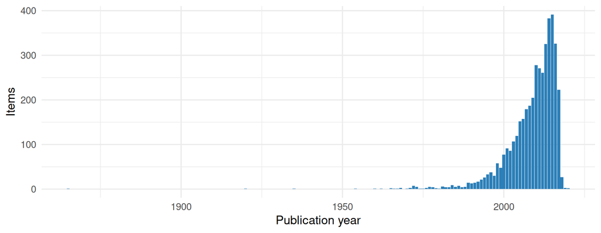

### Types of items

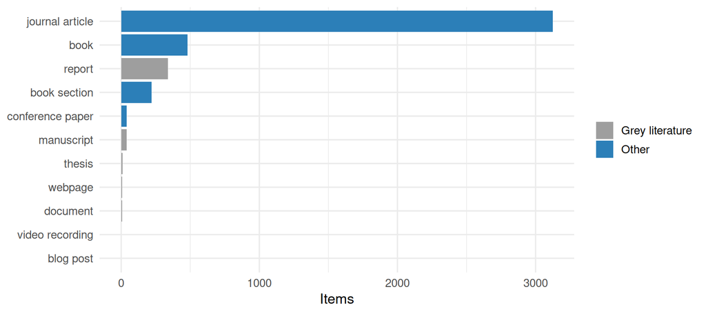

### Open access

Open access status of the publications found in OpenAlex. *Gold* and *diamond*: open in an open access journal; *hybrid*: open in a subscription journal; *green*: an open copy is in a repository; *bronze*: free to read on the publisher’s site; *closed*: not openly available.

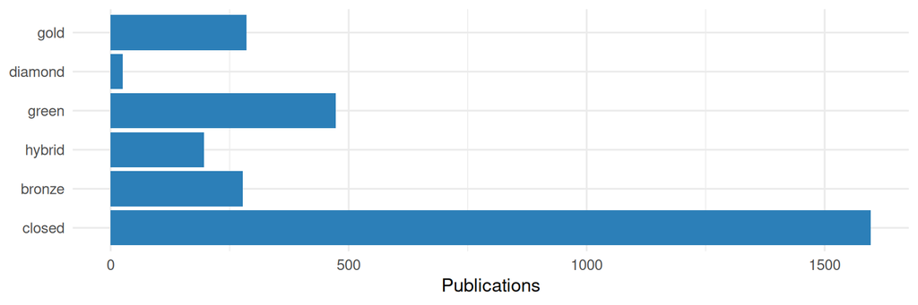

### Most frequent journals

| Journal | Items |
| --- | --- |
| Science | 131 |
| Nature | 83 |
| Proceedings of the National Academy of Sciences | 82 |
| Biological Conservation | 57 |
| Ecological Economics | 54 |
| Conservation Biology | 53 |
| Global Change Biology | 52 |
| Global Environmental Change | 51 |
| Land Use Policy | 50 |
| PLoS ONE | 44 |

### Countries of the authors

Number of publications with at least one author from the country, for the publications found in OpenAlex.

| Country | Publications |
| --- | --- |
| United States | 1238 |
| United Kingdom | 503 |
| Australia | 358 |
| Germany | 300 |
| Netherlands | 271 |
| Canada | 223 |
| France | 210 |
| Brazil | 165 |
| Italy | 144 |
| South Africa | 144 |
| Sweden | 139 |
| China | 129 |
| Switzerland | 127 |
| Belgium | 126 |
| Spain | 118 |

## How the checks work

**NoteDetails of the checks**

#### identifiers

##### DOI coverage (`met_id_doi`)

Number and share of items with a valid DOI, and items whose DOI field is filled but contains no valid DOI. DOIs are extracted with `openalexPro::extract_doi()` and lower cased.

##### ISBN coverage (`met_id_isbn`)

Number and share of items with an ISBN, overall and for the item types which should have one (`book`, `bookSection`).

##### ISSN coverage (`met_id_issn`)

Number and share of items with an ISSN, overall and for the item types which should have one (`journalArticle`, `magazineArticle`).

##### ISSN not in the standard form (`met_id_issn_form`)

Items whose ISSN field is not in the standard form: each ISSN as `1234-567X` (with hyphen, capital X), several separated by “,”. The ISSNs are checked with their check digit. If all are valid, the standard form is proposed; otherwise the item is listed with the ISSNs which are not valid.

##### DOIs in the wrong field (`met_id_doi_misplaced`)

Items with an empty DOI field but a DOI in the `Url` or `Extra` field. These DOIs are not used for the OpenAlex lookup and should be moved to the DOI field.

##### DOIs in the wrong form (`met_id_doi_form`)

Items whose DOI field contains a valid DOI, but not as a bare DOI: as a link (`https://doi.org/10.…`), with a prefix (`doi:`, `DOI`), URL-encoded (`%5B` for `[`) or with spaces or other characters around it. Citation styles add the link themselves, so a link in the DOI field appears twice in a bibliography. The bare DOI is the one recognised by `openalexPro::extract_doi()`, keeping its upper and lower case.

##### Items without identifier (`met_id_none`)

Items with none of DOI, ISBN, ISSN or Url. These items can neither be checked against OpenAlex nor easily be retrieved by readers.

##### DOIs found in OpenAlex for items without a DOI (`met_id_candidates`)

For items without a DOI, OpenAlex was searched by title (see [get_doi_candidates()]). The works found are compared with the item: title (ignoring case and punctuation), year and the surname of the first author. A work is a *likely* match if the titles are (nearly) the same (similarity at least 0.95), the years differ by at most 1 and the first authors have the same surname (year or author are not compared if the item has none), and the title has at least 4 words (short titles like “Zoonoses” are too general). It is a *possible* match if the titles are similar (at least 0.8). All likely and possible works with a DOI are kept, sorted per item, best first. DOIs used by another item in the group are noted (the item would be a duplicate).

#### metadata

##### Filled fields per item type (`met_meta_fields`)

Percentage of items with a filled field, per item type, for the main fields: Title, Author, Publication Year, Publication Title, Publisher, DOI, ISBN, ISSN, Url, Abstract Note and Language. Not every field is expected for every item type, e.g. reports have no Publication Title.

##### Problematic publication years (`met_meta_year`)

Items whose date is missing (`missing`), from whose date Zotero could not derive a year (`unparseable`), or whose year lies in the future (`future`).

##### Duplicate items (`met_meta_duplicates`)

Items which are in the group more than once, identified by the same DOI, or by the same normalised title (lower case, letters and digits only), publication year and first word of the first author.

##### Language not given as a standard code (`met_meta_language`)

Items whose language is not given as a standard language code, i.e. a two-letter ISO 639-1 code, optionally with a region (`en`, `en-US`), but e.g. as a name (`English`), a three-letter code (`eng`) or in a different spelling (`EN`, `en_us`). Citation styles and other tools only recognise the codes. Where the value is recognised, the standard code is proposed, based on the ISO 639-2 list (R package ISOcodes): codes, three-letter codes and the English names of the languages. Other values, e.g. names in the language itself, several languages or other text, are listed without a proposal.

#### openalex_check

##### Zotero DOIs found in OpenAlex (`met_check_found`)

Valid Zotero DOIs which were / were not found in OpenAlex. A DOI which is not found is either not indexed by OpenAlex or wrong.

##### Retracted works (`met_check_retracted`)

Works flagged as retracted by OpenAlex, with the key of the Zotero item(s) with the same DOI.

##### Wrong DOIs (`met_check_mismatch`)

Items whose DOI points in OpenAlex to a work with a different title or year, which usually means that the wrong DOI is attached to the item. An item is flagged when the title similarity (normalised Levenshtein distance) is below 0.8 or the years differ by more than one.

##### Item type agreement (`met_check_type`)

Zotero item type compared with the OpenAlex work type for items with the same DOI.

##### Missing dates found in OpenAlex (`met_check_date`)

Items without a date whose DOI was found in OpenAlex: the publication date in OpenAlex is proposed. OpenAlex gives 1 January when only the year is known, so such dates are proposed as the year only. Items whose DOI points to a different publication are left out.

##### Empty fields found in OpenAlex (`met_check_fill`)

Journal articles with an empty journal, volume, issue or pages field whose DOI was found in OpenAlex with these details: the values in OpenAlex are proposed. The journal is only taken if the publication is in a journal in OpenAlex (not e.g. a repository). Page ranges which end before they start (e.g. `1260-2`, shortened or wrong) are not proposed. Items whose DOI points to a different publication are left out.

##### OpenAlex ID in the Extra field (`met_check_openalex_id`)

Items whose DOI was found in OpenAlex, compared with the OpenAlex ID noted in their Extra field (a line `OpenAlex: W…`). Items without such a line can get it, which links them to OpenAlex for later checks. Items with a different ID are listed for checking: OpenAlex merges records, and the ID of a merged record redirects to the new one. Items whose DOI points to a different publication are left out.

##### OpenAlex ID in the Extra field not valid (`met_check_extra_id`)

Checks the lines `OpenAlex: …` in the Extra field (looked up by [get_extra_ids()]). A line is not valid if - it is not an OpenAlex work ID (`W` and digits), - the item has several lines with different IDs, - the ID is not in OpenAlex (wrong, or merged into another record), or - the work is a different publication: its DOI is not the DOI of the item, or, for items without DOI, its title is not similar (similarity below 0.8, see [title_similarity()]).

#### profile

##### Publication years (`met_prof_year`)

Number of items per publication year, with cumulative counts. Items without a year are counted as `NA`.

##### Open access status (`met_prof_oa`)

OpenAlex open access status (gold, diamond, green, hybrid, bronze, closed) of the works, overall and per publication year.

##### Top journals (`met_prof_journals`)

The 50 most frequent journals, from the Publication Title in Zotero and the source of the primary location in OpenAlex. Ties at rank 50 are included.

##### Author countries (`met_prof_countries`)

Number of works with at least one author affiliated with an institution in a country, per country (ISO 3166-1 alpha-2 codes from OpenAlex).

##### Item types and grey literature (`met_prof_types`)

Number of items per item type (Zotero) or work type (OpenAlex), and the share of grey literature, i.e. reports, theses, dissertations, web pages, documents, presentations, manuscripts, blog posts and preprints.

##### Languages (`met_prof_language`)

Languages as entered, and normalised to two letter codes (lower case, region removed, English spellings mapped to `en`). Inconsistent codes in the language as entered are a quality issue in themselves.

#### maintenance

##### Group activity (`met_maint_activity`)

Items added per month, and items added / modified in the 30 days before the metrics were calculated.

##### Items without tags (`met_maint_tags`)

Items without manual tags. Automatic tags, e.g. keywords imported from the publisher, are ignored.

IPBES Literature Report 0.4.0 · [source code on GitHub](https://github.com/IPBES-Data/IPBES.LiteratureReport) (© IPBES.LiteratureReport authors, [MIT licence](https://opensource.org/license/mit)) · reports and data on this website: [CC0 1.0](https://creativecommons.org/publicdomain/zero/1.0/) (no rights reserved)